# R Workshop

Geoffrey Hannigan, PhD

*ghannig@umich.edu* | *@iprophage*

## Introduction

This is an R markdown file of the R workshop notes. This shows both the code and the output after it is run in R. The shaded regions are the R code to be run. The white boxes show the output as seen in R. The plots generated are also shown in this markdown folder.

Because this is a short workshop (we could spend a whole course on this subject), the goal is to build a basic set of skills that will equip us to go on to practice/use R more on our own. R is a complex language/environment that takes a long time to master, but this is a solid first step toward that mastery.

## Part 1: R Basics

### Introduction to RStudio

R studio is a great tool for easily using R. You can download R studio by visiting the following link:

http://www.rstudio.com/

RStudio sections allow for scripting, running scripts, and visualizing plots, variables, and packages (more on these later). We will be using RStudio for this workshop.

### Basic R Functions

You can perform functions in R by entering commands into the R command prompt. Some examples are basic addition and multiplication.

```r
2 + 2
```

```
## [1] 4
```

```r
3 * 3
```

```
## [1] 9
```

Comments are sections of code that are not run in R. This allows you to type whatever you want after the number symbol. This is important for adding comments to your code that describe what you are doing.

```r
2 + 2 #Y ou can use a comment to mention the answer is 4
```

```
## [1] 4
```

Variables are letters or words that represent a value, just like you use in algebra. These can be assigned using an arrow (<-).

```r
x = 5
y <- 4*4 # This will assign the result of the equation as y
# Then we can run it to make sure it worked
y
```

```
## [1] 16
```

Variables can be used just like the values they represent. An example is adding the two values we assigned above

```r
x + y # The answer is 21, which is the same as 16+5
```

```
## [1] 21
```

### R Functions

R functions are specialized commands that perform more complicated tasks. These are called by typing the name, followed by parenthesis and often some arguments.See the help menu for more details on the specific arguments to include with your function of interest.

An example of a function is c, which *combines* values into a vector (we will discuss vectors in a minute).

```r
c(1,2,3,4,5)
```

```
## [1] 1 2 3 4 5
```

```r
c(1:5) # The colon causes R to go through the digits between the first and second number
```

```
## [1] 1 2 3 4 5
```

### R Packages

R packages are sets of scripts that can be easily added to the working R environment, and often serve specific specialized functions. R packages are often stored in CRAN (the Comprehensive R Archive Network; http://cran.r-project.org/). CRAN packages can be easily installed through the command line. For example, we can try installing the *ggplot* package, a popular package used for plotting data (note that the output will look different if it is already installed on the system).

```r
install.packages("ggplot2")
```

Once the package is installed, we need to load it into the active R session. R does not automatically use all of the installed packages because that could slow the system down.

```r
library("ggplot2") # We will be using this package later
```

### R Vectors

A vector is one-dimensional data structure containing a set of values of the same type. This is one of the most basic data structures in R. A vector is an effective way to store pieces of data together.

Above we made a vector of numbers using the c function.

```r
c(1:10)
```

```
##  [1]  1  2  3  4  5  6  7  8  9 10
```

A specific value can be extracted from a vector using square brackets

```r
c(1:10)[3] # Returns the third value of the vector (counting starts at one)
```

```
## [1] 3
```

To illustrate a more powerful use of an R vector, we can perform an arithmetic function on all of the vetor values.

```r
c(1:10) * 5 # The result is a vector with each value multiplied by five
```

```
##  [1]  5 10 15 20 25 30 35 40 45 50
```

There are a lot of other useful functions for R vectors, which we can continue to explore in greater depth.

```r
z <- c(1:10) # Save vector to variable
length(z) # Get the number of values in the vector z
```

```
## [1] 10
```

```r
mean(z) # Calulate the mean of the vector z
```

```
## [1] 5.5
```

### Data Frames

Now for a data frame, a slightly more sophisticated data structure. A data frame is basically a list of vectors of equal length. It is a tool for storing data tables, and is conceptually similar to a spreadsheet in MS Excel As an example, we can look at the “iris” plant dataset, which is already included in R. To see the data frame, simply type its name, or use the View function in RStudio.

```r
iris
```

```
##     Sepal.Length Sepal.Width Petal.Length Petal.Width    Species
## 1            5.1         3.5          1.4         0.2     setosa
## 2            4.9         3.0          1.4         0.2     setosa
## 3            4.7         3.2          1.3         0.2     setosa
## 4            4.6         3.1          1.5         0.2     setosa
## 5            5.0         3.6          1.4         0.2     setosa
## 6            5.4         3.9          1.7         0.4     setosa
## 7            4.6         3.4          1.4         0.3     setosa
## 8            5.0         3.4          1.5         0.2     setosa
## 9            4.4         2.9          1.4         0.2     setosa
## 10           4.9         3.1          1.5         0.1     setosa
## 11           5.4         3.7          1.5         0.2     setosa
## 12           4.8         3.4          1.6         0.2     setosa
## 13           4.8         3.0          1.4         0.1     setosa
## 14           4.3         3.0          1.1         0.1     setosa
```

[output cut: 136 more lines]

```r
View(iris)
```

The column names can be listed as a vector.

```r
colnames(iris)
```

```
## [1] "Sepal.Length" "Sepal.Width"  "Petal.Length" "Petal.Width"
## [5] "Species"
```

Like a vector, a row or column can be extracted using square brackets.

```r
iris[2,] # Show the second row of the data frame
```

```
##   Sepal.Length Sepal.Width Petal.Length Petal.Width Species
## 2          4.9           3          1.4         0.2  setosa
```

```r
iris[,2] # Show the second column of the data frame as a vector
```

```
##   [1] 3.5 3.0 3.2 3.1 3.6 3.9 3.4 3.4 2.9 3.1 3.7 3.4 3.0 3.0 4.0 4.4 3.9
##  [18] 3.5 3.8 3.8 3.4 3.7 3.6 3.3 3.4 3.0 3.4 3.5 3.4 3.2 3.1 3.4 4.1 4.2
##  [35] 3.1 3.2 3.5 3.6 3.0 3.4 3.5 2.3 3.2 3.5 3.8 3.0 3.8 3.2 3.7 3.3 3.2
##  [52] 3.2 3.1 2.3 2.8 2.8 3.3 2.4 2.9 2.7 2.0 3.0 2.2 2.9 2.9 3.1 3.0 2.7
##  [69] 2.2 2.5 3.2 2.8 2.5 2.8 2.9 3.0 2.8 3.0 2.9 2.6 2.4 2.4 2.7 2.7 3.0
##  [86] 3.4 3.1 2.3 3.0 2.5 2.6 3.0 2.6 2.3 2.7 3.0 2.9 2.9 2.5 2.8 3.3 2.7
## [103] 3.0 2.9 3.0 3.0 2.5 2.9 2.5 3.6 3.2 2.7 3.0 2.5 2.8 3.2 3.0 3.8 2.6
## [120] 2.2 3.2 2.8 2.8 2.7 3.3 3.2 2.8 3.0 2.8 3.0 2.8 3.8 2.8 2.8 2.6 3.0
## [137] 3.4 3.1 3.0 3.1 3.1 3.1 2.7 3.2 3.3 3.0 2.5 3.0 3.4 3.0
```

```r
iris[,-2] # Show everything except the second column
```

```
##     Sepal.Length Petal.Length Petal.Width    Species
## 1            5.1          1.4         0.2     setosa
## 2            4.9          1.4         0.2     setosa
## 3            4.7          1.3         0.2     setosa
## 4            4.6          1.5         0.2     setosa
## 5            5.0          1.4         0.2     setosa
## 6            5.4          1.7         0.4     setosa
## 7            4.6          1.4         0.3     setosa
## 8            5.0          1.5         0.2     setosa
## 9            4.4          1.4         0.2     setosa
## 10           4.9          1.5         0.1     setosa
## 11           5.4          1.5         0.2     setosa
## 12           4.8          1.6         0.2     setosa
## 13           4.8          1.4         0.1     setosa
## 14           4.3          1.1         0.1     setosa
```

[output cut: 136 more lines]

```r
iris[,"Sepal.Width"] # Names can also be used to specify a column
```

```
##   [1] 3.5 3.0 3.2 3.1 3.6 3.9 3.4 3.4 2.9 3.1 3.7 3.4 3.0 3.0 4.0 4.4 3.9
##  [18] 3.5 3.8 3.8 3.4 3.7 3.6 3.3 3.4 3.0 3.4 3.5 3.4 3.2 3.1 3.4 4.1 4.2
##  [35] 3.1 3.2 3.5 3.6 3.0 3.4 3.5 2.3 3.2 3.5 3.8 3.0 3.8 3.2 3.7 3.3 3.2
##  [52] 3.2 3.1 2.3 2.8 2.8 3.3 2.4 2.9 2.7 2.0 3.0 2.2 2.9 2.9 3.1 3.0 2.7
##  [69] 2.2 2.5 3.2 2.8 2.5 2.8 2.9 3.0 2.8 3.0 2.9 2.6 2.4 2.4 2.7 2.7 3.0
##  [86] 3.4 3.1 2.3 3.0 2.5 2.6 3.0 2.6 2.3 2.7 3.0 2.9 2.9 2.5 2.8 3.3 2.7
## [103] 3.0 2.9 3.0 3.0 2.5 2.9 2.5 3.6 3.2 2.7 3.0 2.5 2.8 3.2 3.0 3.8 2.6
## [120] 2.2 3.2 2.8 2.8 2.7 3.3 3.2 2.8 3.0 2.8 3.0 2.8 3.8 2.8 2.8 2.6 3.0
## [137] 3.4 3.1 3.0 3.1 3.1 3.1 2.7 3.2 3.3 3.0 2.5 3.0 3.4 3.0
```

```r
iris[2,2] # Combine the two to the the second field of the second column
```

```
## [1] 3
```

```r
# Another way of specifying the second column of the
# data frame, using the column name
iris$Sepal.Width
```

```
##   [1] 3.5 3.0 3.2 3.1 3.6 3.9 3.4 3.4 2.9 3.1 3.7 3.4 3.0 3.0 4.0 4.4 3.9
##  [18] 3.5 3.8 3.8 3.4 3.7 3.6 3.3 3.4 3.0 3.4 3.5 3.4 3.2 3.1 3.4 4.1 4.2
##  [35] 3.1 3.2 3.5 3.6 3.0 3.4 3.5 2.3 3.2 3.5 3.8 3.0 3.8 3.2 3.7 3.3 3.2
##  [52] 3.2 3.1 2.3 2.8 2.8 3.3 2.4 2.9 2.7 2.0 3.0 2.2 2.9 2.9 3.1 3.0 2.7
##  [69] 2.2 2.5 3.2 2.8 2.5 2.8 2.9 3.0 2.8 3.0 2.9 2.6 2.4 2.4 2.7 2.7 3.0
##  [86] 3.4 3.1 2.3 3.0 2.5 2.6 3.0 2.6 2.3 2.7 3.0 2.9 2.9 2.5 2.8 3.3 2.7
## [103] 3.0 2.9 3.0 3.0 2.5 2.9 2.5 3.6 3.2 2.7 3.0 2.5 2.8 3.2 3.0 3.8 2.6
## [120] 2.2 3.2 2.8 2.8 2.7 3.3 3.2 2.8 3.0 2.8 3.0 2.8 3.8 2.8 2.8 2.6 3.0
## [137] 3.4 3.1 3.0 3.1 3.1 3.1 2.7 3.2 3.3 3.0 2.5 3.0 3.4 3.0
```

We can perform calculations on columns (or rows) of the data frame.

```r
mean(iris$Sepal.Width) # Calculate the mean of the sepal width column values
```

```
## [1] 3.057333
```

```r
median(iris$Sepal.Width) # Calculate median
```

```
## [1] 3
```

```r
# Multiply every value of the column by 100
# Output values into a vector
100 * iris$Sepal.Width
```

```
##   [1] 350 300 320 310 360 390 340 340 290 310 370 340 300 300 400 440 390
##  [18] 350 380 380 340 370 360 330 340 300 340 350 340 320 310 340 410 420
##  [35] 310 320 350 360 300 340 350 230 320 350 380 300 380 320 370 330 320
##  [52] 320 310 230 280 280 330 240 290 270 200 300 220 290 290 310 300 270
##  [69] 220 250 320 280 250 280 290 300 280 300 290 260 240 240 270 270 300
##  [86] 340 310 230 300 250 260 300 260 230 270 300 290 290 250 280 330 270
## [103] 300 290 300 300 250 290 250 360 320 270 300 250 280 320 300 380 260
## [120] 220 320 280 280 270 330 320 280 300 280 300 280 380 280 280 260 300
## [137] 340 310 300 310 310 310 270 320 330 300 250 300 340 300
```

### Plotting with ggplot

There are many options for generating plots in R. One of the best options is using the ggplot2 package. This is a little difficult to get used to, but offers a wide range of abilities. Before use, the package needs to be installed and loaded, like we described above using the `library` function.

As an example, we will generate a box plot of sepal widths, grouped by species.Here the function is specified first, followed by the data frame (iris), the column names used for the x and y axes, and an added section (using plus symbol) to specify generation of a box plot.

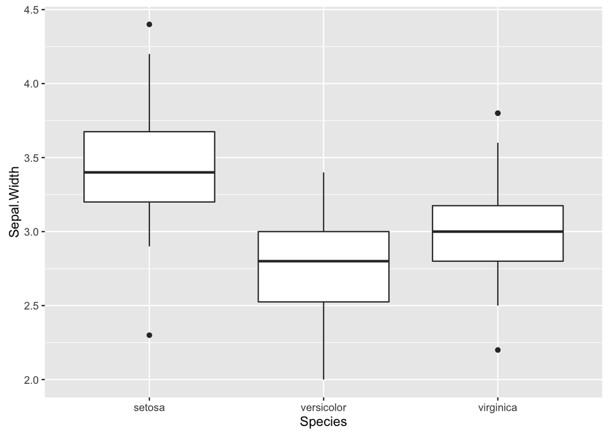

```r
ggplot(iris, aes(x=Species, y=Sepal.Width)) + geom_boxplot()
```

We can make it look different by changing the theme. As the lines start to get long, we can also spread the function across multiple lines.

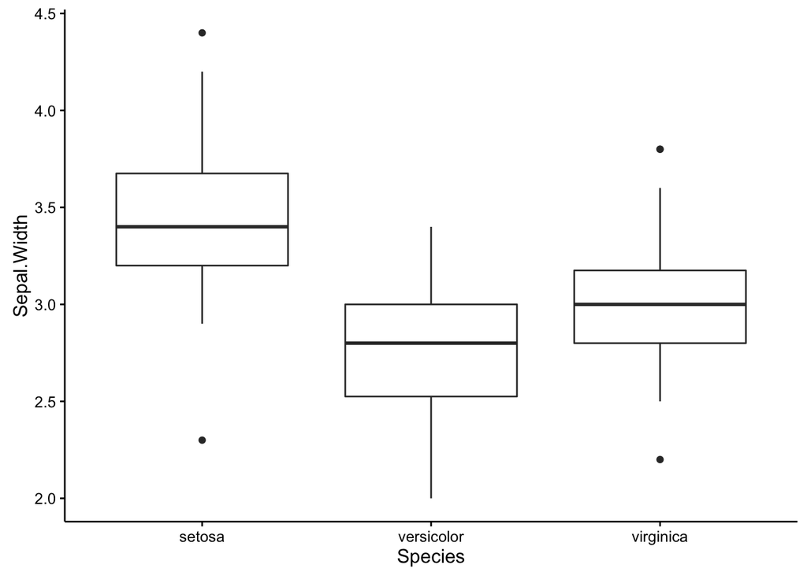

```r
# Add the classic theme
ggplot(iris, aes(x=Species, y=Sepal.Width)) +
  theme_classic() +
  theme(
  axis.line.x = element_line(colour = 'black', size=0.5, linetype='solid'),
  axis.line.y = element_line(colour = 'black', size=0.5, linetype='solid')) +
  geom_boxplot()
```

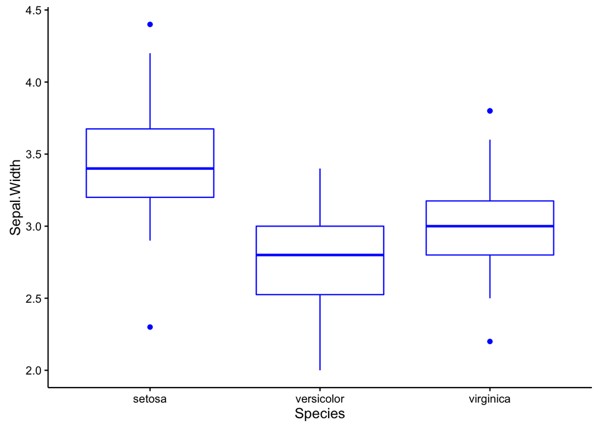

```r
# Add color to the plot
ggplot(iris, aes(x=Species, y=Sepal.Width)) +
  theme_classic() +
  theme(
  axis.line.x = element_line(colour = 'black', size=0.5, linetype='solid'),
  axis.line.y = element_line(colour = 'black', size=0.5, linetype='solid')) +
  geom_boxplot(color="blue")
```

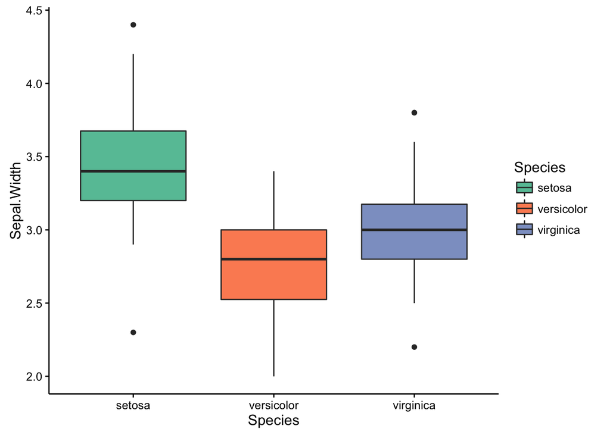

```r
# Add color by group (using a color palette from the color brewer package)
ggplot(iris, aes(x=Species, y=Sepal.Width, fill=Species)) +
  theme_classic() +
  theme(
  axis.line.x = element_line(colour = 'black', size=0.5, linetype='solid'),
  axis.line.y = element_line(colour = 'black', size=0.5, linetype='solid')) +
  geom_boxplot() +
  scale_fill_brewer(palette="Set2")
```

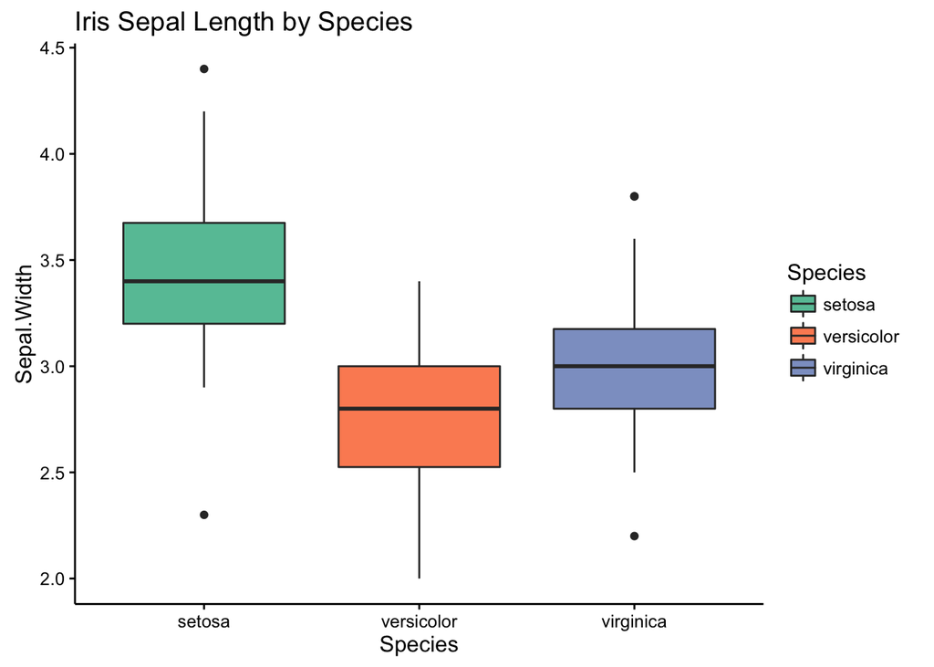

```r
# Add a title to the plot
ggplot(iris, aes(x=Species, y=Sepal.Width, fill=Species)) +
  theme_classic() +
  theme(
  axis.line.x = element_line(colour = 'black', size=0.5, linetype='solid'),
  axis.line.y = element_line(colour = 'black', size=0.5, linetype='solid')) +
  geom_boxplot() +
  scale_fill_brewer(palette="Set2") +
  ggtitle("Iris Sepal Length by Species")
```

# Part 2: Going Through A Real Example

Now we will go through a real example of comparing two groups of values and plotting the results. We are going to use the iris example dataset, which has been saved as a .csv file (this means the values are seperated by “,” symbol). This is a common format that can be used with MS Excel.Before we start working in R, we can open the file in Excel to see what it looks like in an environment we might be more used to. In the future we can save a file as a csv for input into R by simply clicking “Save As” and choosing the csv file type.

It is important that the newline symbols are Unix and not Mac or Windows, which is the format Excel will give the data. We can easily fix newlines in an Excel saved csv by opening it in “TextWrangler” and saving the file again, and selecting the Unix newline characters.

First we want to load the file into R (honestly one of the biggest hurdles when learning R) using the read.delim function. To work with the file later, we will assign it to a variable (see, these variable things are helpful :)). The data table will be saved as a data frame

```r
SepalDF <- read.delim("~/git/RWorkshop/IrisRExampleDataset.csv", sep=",", header=TRUE)
```

We can visualize the data frame in RStudio as a “spreadsheet-like” object.

```r
View(SepalDF)
```

Note the spaces are replaced by dots. We do not want spaces in our dataset.

We can use a histogram to see if the data is normally distributed around a mean.

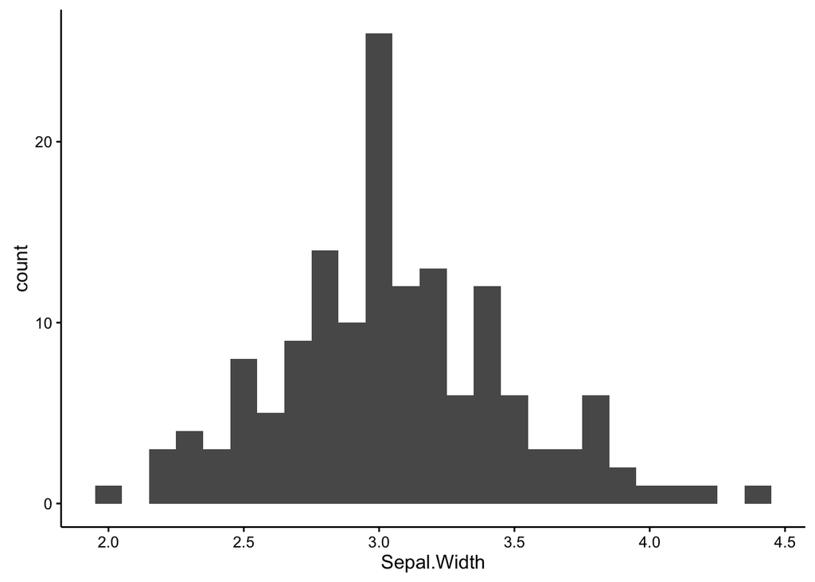

```r
ggplot(SepalDF, aes(x=Sepal.Width)) +
  theme_classic() +
  theme(
  axis.line.x = element_line(colour = 'black', size=0.5, linetype='solid'),
  axis.line.y = element_line(colour = 'black', size=0.5, linetype='solid')) +
  geom_histogram(binwidth = 0.1)
```

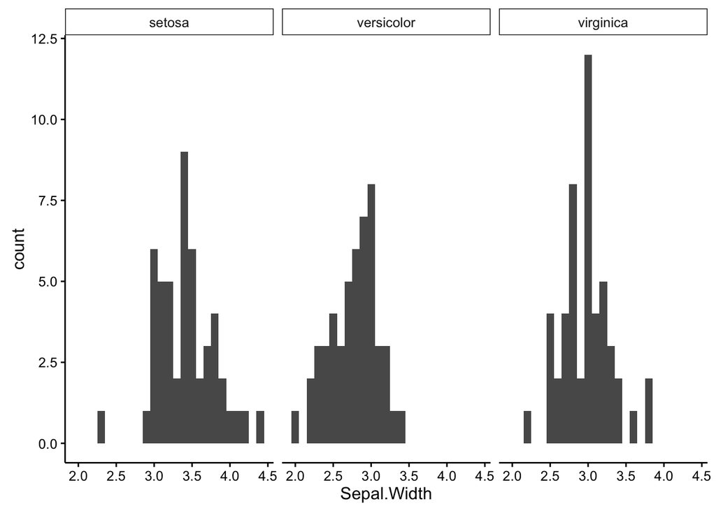

```r
ggplot(SepalDF, aes(x=Sepal.Width)) +
  theme_classic() +
  theme(
  axis.line.x = element_line(colour = 'black', size=0.5, linetype='solid'),
  axis.line.y = element_line(colour = 'black', size=0.5, linetype='solid')) +
  geom_histogram(binwidth = 0.1) +
  facet_grid(~Species)
```

Next we are going to calculate the mean sepal widths for each species. Performing the mean over all the data is very easy.

```r
mean(SepalDF$Sepal.Width)
```

```
## [1] 3.054
```

```r
install.packages("plyr")
```

```r
# Load it into the active R session
library("plyr")
```

No let’s only look at the Setosa and Virginica species. We can remove the Versicolor species using the data frame techniques we mentioned above (this is a little more complicated but we will go through it). We are again saving the new data frame result as a variable

```r
SepalDfTwoSpecies <- SepalDF[-which(SepalDF$Species %in% "versicolor"),]
# Look at the result
SepalDfTwoSpecies
```

```
##     Sepal.Length Sepal.Width Petal.Length Petal.Width   Species
## 1            5.1         3.5          1.4         0.2    setosa
## 2            4.9         3.0          1.4         0.2    setosa
## 3            4.7         3.2          1.3         0.2    setosa
## 4            4.6         3.1          1.5         0.2    setosa
## 5            5.0         3.6          1.4         0.2    setosa
## 6            5.4         3.9          1.7         0.4    setosa
## 7            4.6         3.4          1.4         0.3    setosa
## 8            5.0         3.4          1.5         0.2    setosa
## 9            4.4         2.9          1.4         0.2    setosa
## 10           4.9         3.1          1.5         0.1    setosa
## 11           5.4         3.7          1.5         0.2    setosa
## 12           4.8         3.4          1.6         0.2    setosa
## 13           4.8         3.0          1.4         0.1    setosa
## 14           4.3         3.0          1.1         0.1    setosa
```

[output cut: 86 more lines]

To understand what is going on, we can run the different parts of the function independently instead of all at the same time.

```r
SepalDF$Species # This specifies only the Species column
```

```
##   [1] "setosa"     "setosa"     "setosa"     "setosa"     "setosa"
##   [6] "setosa"     "setosa"     "setosa"     "setosa"     "setosa"
##  [11] "setosa"     "setosa"     "setosa"     "setosa"     "setosa"
##  [16] "setosa"     "setosa"     "setosa"     "setosa"     "setosa"
##  [21] "setosa"     "setosa"     "setosa"     "setosa"     "setosa"
##  [26] "setosa"     "setosa"     "setosa"     "setosa"     "setosa"
##  [31] "setosa"     "setosa"     "setosa"     "setosa"     "setosa"
##  [36] "setosa"     "setosa"     "setosa"     "setosa"     "setosa"
##  [41] "setosa"     "setosa"     "setosa"     "setosa"     "setosa"
##  [46] "setosa"     "setosa"     "setosa"     "setosa"     "setosa"
##  [51] "versicolor" "versicolor" "versicolor" "versicolor" "versicolor"
##  [56] "versicolor" "versicolor" "versicolor" "versicolor" "versicolor"
##  [61] "versicolor" "versicolor" "versicolor" "versicolor" "versicolor"
##  [66] "versicolor" "versicolor" "versicolor" "versicolor" "versicolor"
##  [71] "versicolor" "versicolor" "versicolor" "versicolor" "versicolor"
##  [76] "versicolor" "versicolor" "versicolor" "versicolor" "versicolor"
##  [81] "versicolor" "versicolor" "versicolor" "versicolor" "versicolor"
##  [86] "versicolor" "versicolor" "versicolor" "versicolor" "versicolor"
##  [91] "versicolor" "versicolor" "versicolor" "versicolor" "versicolor"
##  [96] "versicolor" "versicolor" "versicolor" "versicolor" "versicolor"
## [101] "virginica"  "virginica"  "virginica"  "virginica"  "virginica"
## [106] "virginica"  "virginica"  "virginica"  "virginica"  "virginica"
## [111] "virginica"  "virginica"  "virginica"  "virginica"  "virginica"
## [116] "virginica"  "virginica"  "virginica"  "virginica"  "virginica"
## [121] "virginica"  "virginica"  "virginica"  "virginica"  "virginica"
## [126] "virginica"  "virginica"  "virginica"  "virginica"  "virginica"
## [131] "virginica"  "virginica"  "virginica"  "virginica"  "virginica"
## [136] "virginica"  "virginica"  "virginica"  "virginica"  "virginica"
## [141] "virginica"  "virginica"  "virginica"  "virginica"  "virginica"
## [146] "virginica"  "virginica"  "virginica"  "virginica"  "virginica"
```

We can use the `%in%` operator to determine which rows of the `Species` column match “versicolor”. The output is a vector with the numbers of each row that matched.

```r
which(SepalDF$Species %in% "versicolor")
```

```
##  [1]  51  52  53  54  55  56  57  58  59  60  61  62  63  64  65  66  67
## [18]  68  69  70  71  72  73  74  75  76  77  78  79  80  81  82  83  84
## [35]  85  86  87  88  89  90  91  92  93  94  95  96  97  98  99 100
```

The minus sign adds a minus sign to each of the row numbers. This will be used to exclude those rows instead of include them.

```r
-which(SepalDF$Species %in% "versicolor")
```

```
##  [1]  -51  -52  -53  -54  -55  -56  -57  -58  -59  -60  -61  -62  -63  -64
## [15]  -65  -66  -67  -68  -69  -70  -71  -72  -73  -74  -75  -76  -77  -78
## [29]  -79  -80  -81  -82  -83  -84  -85  -86  -87  -88  -89  -90  -91  -92
## [43]  -93  -94  -95  -96  -97  -98  -99 -100
```

As we mentioned before, square brackets can be used to specify positions in vectors, as well as data frames. The format is `dataframe[row,column]`. `dataframe[1,]` will return the first row of the data frame, while `dataframe[-1,]` will return all of the rows *except* the first. We will use our vector above of minus sign row numbers to specify the rows we want to exclude, which means we are excluding all of the rows that match “versicolor”.

```r
SepalDF[-which(SepalDF$Species %in% "versicolor"),]
```

```
##     Sepal.Length Sepal.Width Petal.Length Petal.Width   Species
## 1            5.1         3.5          1.4         0.2    setosa
## 2            4.9         3.0          1.4         0.2    setosa
## 3            4.7         3.2          1.3         0.2    setosa
## 4            4.6         3.1          1.5         0.2    setosa
## 5            5.0         3.6          1.4         0.2    setosa
## 6            5.4         3.9          1.7         0.4    setosa
## 7            4.6         3.4          1.4         0.3    setosa
## 8            5.0         3.4          1.5         0.2    setosa
## 9            4.4         2.9          1.4         0.2    setosa
## 10           4.9         3.1          1.5         0.1    setosa
## 11           5.4         3.7          1.5         0.2    setosa
## 12           4.8         3.4          1.6         0.2    setosa
## 13           4.8         3.0          1.4         0.1    setosa
## 14           4.3         3.0          1.1         0.1    setosa
```

[output cut: 86 more lines]

```r
# View the new data frame
View(SepalDfTwoSpecies)
```

Now we can easily calculate the mean and std error of the two groups using the plyr package we loaded above.

```r
SepalStats <- ddply(SepalDfTwoSpecies, # The dataframe that we wanted to use
                    c("Species"), # A vector containing the grouping
                    summarise, # Tell it we want to summarize the data
                    mean=mean(Sepal.Width), # Calculate the mean Sepal Width for each group
                    std_deviation = sd(Sepal.Width), # Calculate standard deviation
                    std_error = sd(Sepal.Width)/sqrt(length(Sepal.Width))) # Calculate standard error
# We can view the stats in the variable
View(SepalStats)
```

We can use this data to graph the results as a bar plot using ggplot. Use `geom_bar` to create a `bar plot`. Use `geom_errorbar` to set the error bars using the column names in our sepal stats data frame.

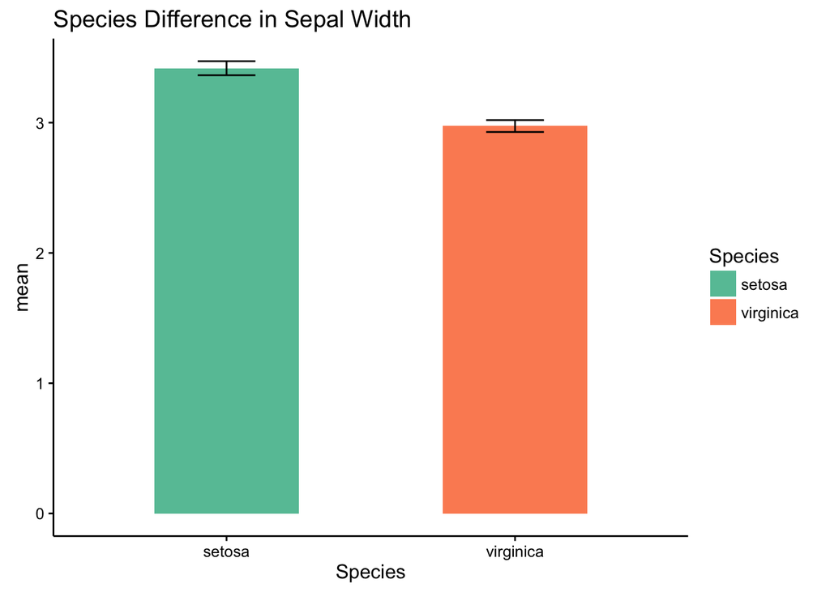

```r
ggplot(SepalStats, aes(x=Species, y=mean, fill=Species)) +
  theme_classic() +
  theme(
  axis.line.x = element_line(colour = 'black', size=0.5, linetype='solid'),
  axis.line.y = element_line(colour = 'black', size=0.5, linetype='solid')) +
  geom_bar(position=position_dodge(), stat="identity", width=0.5) +
  geom_errorbar(aes(ymin=mean-std_error, ymax=mean+std_error), width=.2) +
  scale_fill_brewer(palette="Set2") +
  ggtitle("Species Difference in Sepal Width")
```

This data looks like it is probably significantly different, but we want to actually run the stats. A very basic statistical test is a t-test for differences between two groups. This assumes normally distributed data, which we supported above with the histograms. We can perform this test easily using the basic r `t.test` function.

```r
SepalTTest <- t.test(Sepal.Width ~ Species, SepalDfTwoSpecies)
# See the statistics results
SepalTTest
```

```
##
##  Welch Two Sample t-test
##
## data:  Sepal.Width by Species
## t = 6.2894, df = 95.395, p-value = 9.586e-09
## alternative hypothesis: true difference in means is not equal to 0
## 95 percent confidence interval:
##  0.3038584 0.5841416
## sample estimates:
##    mean in group setosa mean in group virginica
##                   3.418                   2.974
```

```r
# An example if you just want to see the p-value
SepalTTest$p.value
```

```
## [1] 9.586039e-09
```

And there we have it, the two groups are significantly different.